# COVID Project

Student

2025-07-14

# Project Requirements & Question of interest

Import, tidy and analyze the COVID19 dataset from the Johns Hopkins github site. This is the same dataset I used in class. Feel free to repeat and reuse what I did if you want to. Be sure your project is reproducible and contains some visualization and analysis that is unique to your project. You may use the data to do any analysis that is of interest to you. You should include at least two visualizations and one model. Be sure to identify any bias possible in the data and in your analysis

All code will be present in document, but placed in the ‘show’ button to keep the document and visualizations cleaner. There is also a ‘Code’ drop down in the upper right hand corner of the document that you can choose to show all or hide all code if helpful.

This project is to review a COVID 19 datasest that tracks new COVID 19 cases as well as deaths over a period of approximately 3 years. The report summarizes and reviews this data and attempts to forecast US deaths based on cases as well as a date element (month years).

## Read in the data

See the ‘show’ button to reveal all codes in chunks

```r
library(tidyverse)
library(lubridate)
# library(dplyr)
library(ggplot2)


url_in <- 'https://raw.githubusercontent.com/CSSEGISandData/COVID-19/master/csse_covid_19_data/csse_covid_19_time_series/'

file_names <- c('time_series_covid19_confirmed_global.csv',
                'time_series_covid19_deaths_global.csv',
                'time_series_covid19_confirmed_US.csv',
                'time_series_covid19_deaths_US.csv')

urls <-str_c(url_in, file_names)

global_cases <- read_csv(urls[1])
global_deaths <- read_csv(urls[2])
US_cases <- read_csv(urls[3])
US_deaths <- read_csv(urls[4])

uid_lookup_url <- "https://raw.githubusercontent.com/CSSEGISandData/COVID-19/master/csse_covid_19_data/UID_ISO_FIPS_LookUp_Table.csv"

uid <- read_csv(uid_lookup_url) %>%
  select(-c(Lat, Long_, Combined_Key, code3, iso2, iso3, Admin2))
```

## Global Data Summaries

```r
# global information
global_cases <- global_cases %>%
  pivot_longer(cols = -c('Province/State',
                         'Country/Region',
                         Lat,
                         Long),
               names_to = 'date',
               values_to = 'cases') %>%
  select(-c(Lat,Long))

global_deaths <- global_deaths %>%
  pivot_longer(cols = -c('Province/State',
                         'Country/Region',
                         Lat,
                         Long),
               names_to = 'date',
               values_to = 'deaths') %>%
  select(-c(Lat,Long))


# transform data
global <- global_cases %>%
  full_join(global_deaths) %>%
  rename(Country_Region = 'Country/Region',
         Province_State = 'Province/State') %>%
  mutate(date = mdy(date))

global <- global %>%
  filter(cases > 0)

global <- global %>%
  unite("Combined_Key",
        c(Province_State, Country_Region),
        sep = ", ",
        na.rm = TRUE,
        remove = FALSE)

global <- global %>%
  left_join(uid,
            by = c("Province_State", "Country_Region")) %>%
  select(-c(UID, FIPS)) %>%
  select(Province_State,
         Country_Region,
         date,
         cases,
         deaths,
         Population,
         Combined_Key)

global <- global %>%
  mutate(Province_State = as.factor(Province_State),
         Country_Region = as.factor(Country_Region),
         Combined_Key = as.factor(Combined_Key))%>%
  select(Province_State,
         Country_Region,
         Combined_Key,
         date,
         Population,
         cases,
         deaths)


summary(global)
```

```
##    Province_State          Country_Region             Combined_Key
##  Anhui    :  1143   China         : 38774   Anhui, China    :  1143
##  Beijing  :  1143   Canada        : 16010   Beijing, China  :  1143
##  Chongqing:  1143   United Kingdom: 14203   Chongqing, China:  1143
##  Fujian   :  1143   France        : 12929   Fujian, China   :  1143
##  Guangdong:  1143   Australia     :  8944   Guangdong, China:  1143
##  (Other)  : 90423   Netherlands   :  5447   Guangxi, China  :  1143
##  NA's     :210689   (Other)       :210520   (Other)         :299969
##       date              Population            cases               deaths
##  Min.   :2020-01-22   Min.   :6.700e+01   Min.   :        1   Min.   :      0
##  1st Qu.:2020-12-12   1st Qu.:7.866e+05   1st Qu.:     1316   1st Qu.:      7
##  Median :2021-09-16   Median :6.948e+06   Median :    20365   Median :    214
##  Mean   :2021-09-11   Mean   :2.890e+07   Mean   :  1032863   Mean   :  14405
##  3rd Qu.:2022-06-15   3rd Qu.:2.914e+07   3rd Qu.:   271281   3rd Qu.:   3665
##  Max.   :2023-03-09   Max.   :1.380e+09   Max.   :103802702   Max.   :1123836
##                       NA's   :6729
```

Some populations are missing as well as some non-countries exist.

The populations are missing from some big countries (Canada, China).  
We would want to find an additional data source if we were going to use Population in a meaningful way. It is also not clear what date range the ‘Population’ is from, so it could be misleading.

And there is information from 2 Olympics which may or may not be needed

```r
global %>%
  group_by(Country_Region) %>%
  summarise(Population = max(Population)) %>%
  filter(is.na(Population))
```

```
## # A tibble: 7 × 2
##   Country_Region       Population
##   <fct>                     <dbl>
## 1 Antarctica                   NA
## 2 Canada                       NA
## 3 China                        NA
## 4 Diamond Princess             NA
## 5 MS Zaandam                   NA
## 6 Summer Olympics 2020         NA
## 7 Winter Olympics 2022         NA
```

## US Data Summaries

```r
# US information
US_cases <- US_cases %>%
  pivot_longer(cols = -(UID:Combined_Key),
               names_to = 'date',
               values_to = 'cases') %>%
  select(Admin2:cases) %>%
  mutate(date = mdy(date)) %>%
  select(-c(Lat, Long_))

US_deaths <- US_deaths %>%
  pivot_longer(cols = -(UID:Population),
               names_to = 'date',
               values_to = 'deaths') %>%
  select(Admin2:deaths) %>%
  mutate(date = mdy(date)) %>%
  select(-c(Lat, Long_))

US <- US_cases %>%
  full_join(US_deaths)

US <- US %>%
  mutate(County = as.factor(Admin2),
         Province_State = as.factor(Province_State),
         Country_Region = as.factor(Country_Region),
         Combined_Key = as.factor(Combined_Key)) %>%
  select(County,
         Province_State,
         Country_Region,
         Combined_Key,
         date,
         Population,
         cases,
         deaths)

summary(US)
```

```
##         County         Province_State    Country_Region
##  Unassigned:  59436   Texas   : 292608   US:3819906
##  Washington:  35433   Georgia : 184023
##  Jefferson :  29718   Virginia: 154305
##  Franklin  :  28575   Kentucky: 139446
##  Jackson   :  27432   Missouri: 134874
##  (Other)   :3632454   Kansas  : 122301
##  NA's      :   6858   (Other) :2792349
##                         Combined_Key          date
##  Abbeville, South Carolina, US:   1143   Min.   :2020-01-22
##  Acadia, Louisiana, US        :   1143   1st Qu.:2020-11-02
##  Accomack, Virginia, US       :   1143   Median :2021-08-15
##  Ada, Idaho, US               :   1143   Mean   :2021-08-15
##  Adair, Iowa, US              :   1143   3rd Qu.:2022-05-28
##  Adair, Kentucky, US          :   1143   Max.   :2023-03-09
##  (Other)                      :3813048
##    Population           cases             deaths
##  Min.   :       0   Min.   :  -3073   Min.   :  -82.0
##  1st Qu.:    9917   1st Qu.:    330   1st Qu.:    4.0
##  Median :   24892   Median :   2272   Median :   37.0
##  Mean   :   99604   Mean   :  14088   Mean   :  186.9
##  3rd Qu.:   64979   3rd Qu.:   8159   3rd Qu.:  122.0
##  Max.   :10039107   Max.   :3710586   Max.   :35545.0
##
```

There are some negative cases and deaths, which doesn’t make logical sense.  
We should review these and determine if we need to smooth or impute to 0.  
Cursory look appears like we need to impute to 0 as these are random numbers in the middle of a date range (and negative).

```r
US %>%
  filter(cases < 0) %>%
  group_by(Province_State, County, date) %>%
  summarise(cases = min(cases),
            deaths = min(deaths))
```

```
## # A tibble: 3 × 5
## # Groups:   Province_State, County [2]
##   Province_State County     date       cases deaths
##   <fct>          <fct>      <date>     <dbl>  <dbl>
## 1 North Carolina Unassigned 2022-11-09   -34     -6
## 2 South Carolina Unassigned 2022-05-05 -3073    -82
## 3 South Carolina Unassigned 2022-05-06 -3073    -82
```

```r
US <- US %>%
  mutate(cases = ifelse(is.na(cases), 0, cases),
         deaths = ifelse(is.na(deaths), 0, deaths),
         cases = ifelse(cases < 0, 0, cases),
         deaths = ifelse(deaths < 0, 0, deaths))
```

### Additional looks at US data

```r
US_by_state <- US %>%
  group_by(Province_State, Country_Region, date) %>%
  summarize(cases = sum(cases),
            deaths = sum(deaths),
            Population = sum(Population)) %>%
  mutate(deaths_per_mill = deaths * 1000000 / Population) %>%
  select(Province_State, Country_Region, date,
         cases, deaths, deaths_per_mill, Population) %>%
  ungroup()

US_totals <- US_by_state %>%
  group_by(Country_Region, date) %>%
  summarize(cases = sum(cases),
            deaths = sum(deaths),
            Population = sum(Population)) %>%
  mutate(deaths_per_mill = deaths * 1000000 / Population) %>%
  select(Country_Region, date,
         cases, deaths, deaths_per_mill, Population) %>%
  ungroup()

US_by_state <- US_by_state %>%
  mutate(new_cases = cases - lag(cases),
         new_deaths = deaths - lag(deaths))


US_totals <- US_totals %>%
  mutate(new_cases = cases - lag(cases),
         new_deaths = deaths - lag(deaths))

US_totals <- US_totals %>%
  mutate(new_cases = ifelse(is.na(new_cases), 0, new_cases),
         new_deaths = ifelse(is.na(new_deaths), 0, new_deaths))

US_state_totals <- US_by_state %>%
  group_by(Province_State) %>%
  summarise(deaths = max(deaths),
            cases = max(cases),
            population = max(Population),
            cases_per_thou = 1000*cases/population,
            deaths_per_thou = 1000*deaths/population) %>%
  filter(cases > 0, population > 0)

US_totals_dk <- US_totals

US_totals_dk <- US_totals_dk %>%
  mutate(year = factor(year(date), levels = c('2020', '2021', '2022', '2023')),
         month = factor(month(date), levels = c(1,2,3,4,5,6,7,8,9,10,11,12)))

US_totals_dk$Month_Yr <- format(US_totals_dk$date, "%Y%m")
```

Smoothing the data by month and year, shows a big spike in new cases post-holidays in Jan 2022

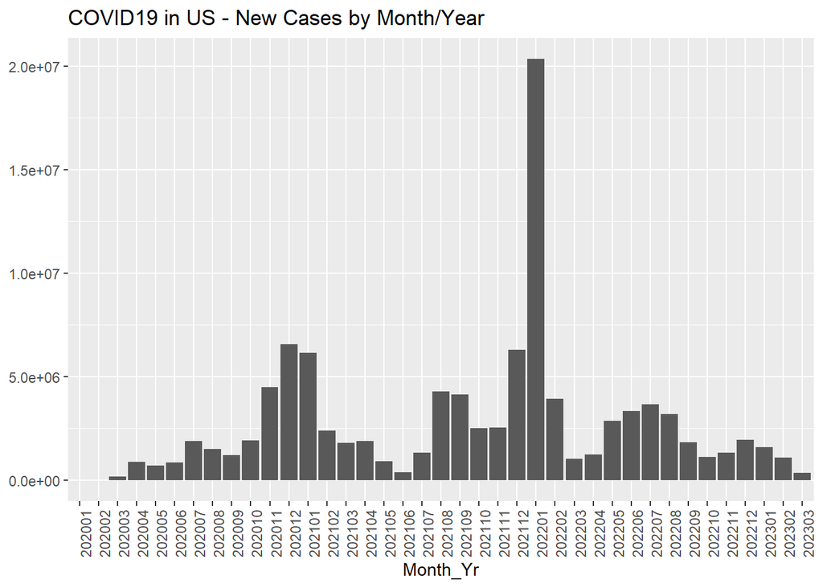

```r
# new cases by month year
US_totals_dk %>%
  group_by(Month_Yr) %>%
  summarise(new_cases = sum(new_cases),
            new_deaths = sum(new_deaths)) %>%
  ggplot(aes(x = Month_Yr, y = new_cases)) +
  geom_bar(stat = 'identity') +
  theme(legend.position = 'bottom',
      axis.text.x = element_text(angle = 90)) +
  labs(title = "COVID19 in US - New Cases by Month/Year", y = NULL)
```

But there didn’t seem to be an agreessive spike in deaths at the same time…

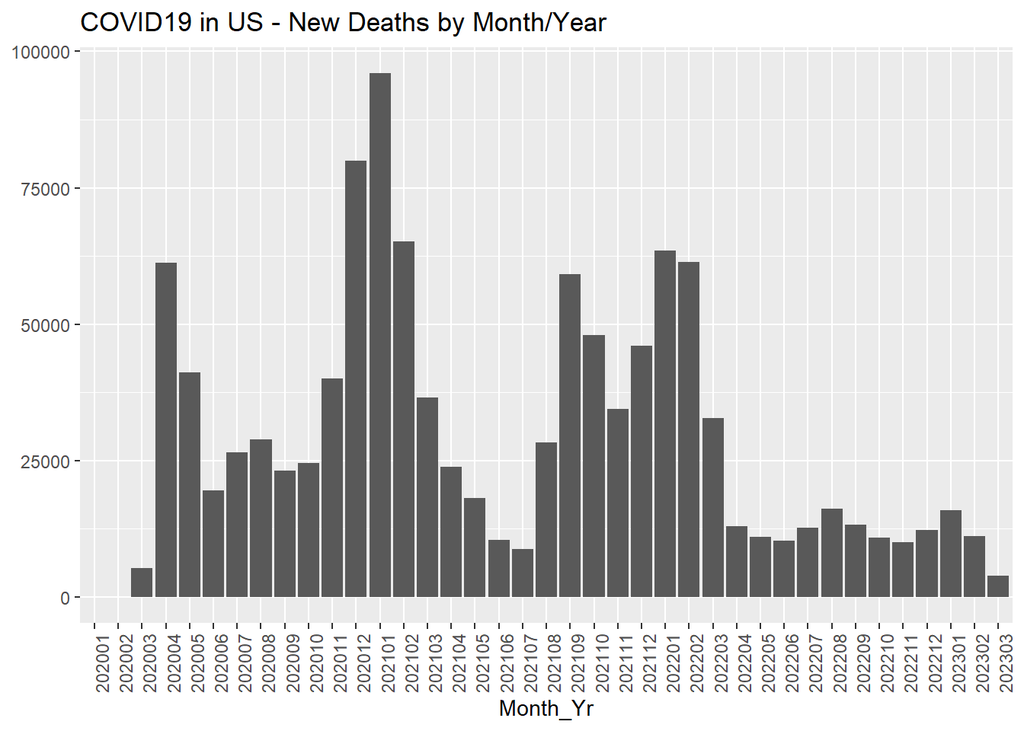

```r
# new deaths by month year
US_totals_dk %>%
  group_by(Month_Yr) %>%
  summarise(new_cases = sum(new_cases),
            new_deaths = sum(new_deaths)) %>%
  ggplot(aes(x = Month_Yr, y = new_deaths)) +
  geom_bar(stat = 'identity') +
  theme(legend.position = 'bottom',
        axis.text.x = element_text(angle = 90)) +
  labs(title = "COVID19 in US - New Deaths by Month/Year", y = NULL)
```

When looking at the new deaths to new cases ratio around the same early 2022 months, you can see a slight uptick in deaths per new cases in March 2022, perhaps revealing the lag in case onset to death.

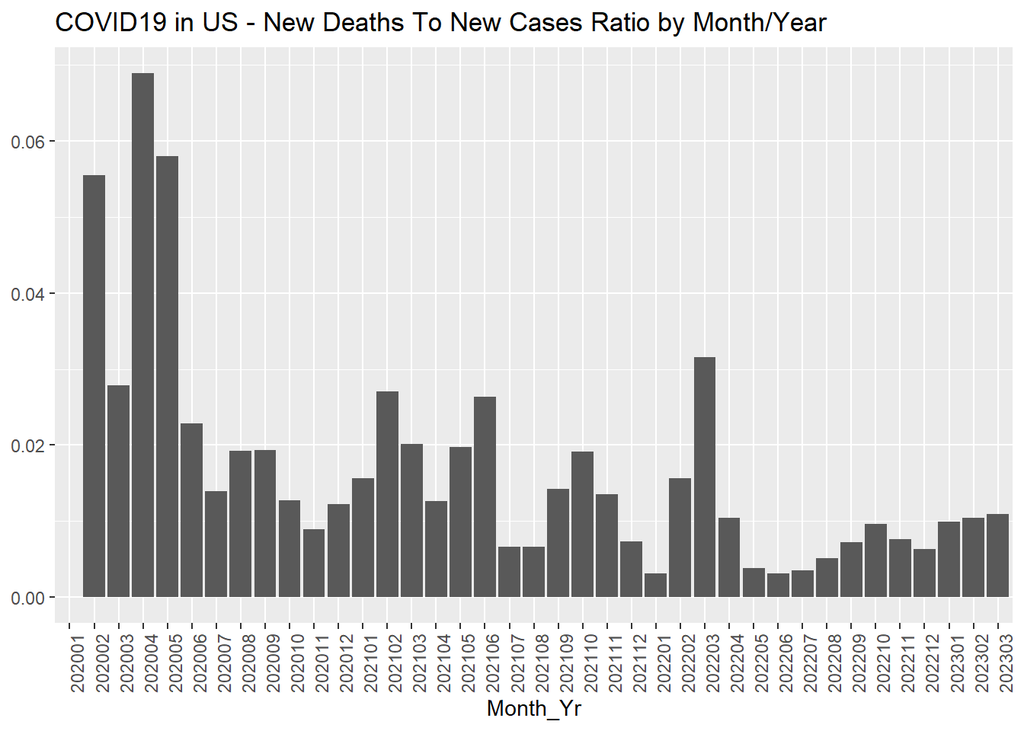

```r
# new deaths over cases by month year
US_totals_dk %>%
  group_by(Month_Yr) %>%
  summarise(new_cases = sum(new_cases),
            new_deaths = sum(new_deaths)) %>%
  mutate(new_cases_death_ratio = new_deaths/new_cases) %>%
  ggplot(aes(x = Month_Yr, y = new_cases_death_ratio)) +
  geom_bar(stat = 'identity') +
  theme(legend.position = 'bottom',
        axis.text.x = element_text(angle = 90)) +
  labs(title = "COVID19 in US - New Deaths To New Cases Ratio by Month/Year", y = NULL)
```

### Additional Opportunities for analysis

- Look at the lag from new case to death over the time period to see if you could find a change in time from onset to death of the disease.
- collapse the time data more to quaters to see seasonal trends

# Forecasting Models

```r
mod <- lm(new_deaths ~ new_cases + Month_Yr, data = US_totals_dk)
summary(mod)
```

```
##
## Call:
## lm(formula = new_deaths ~ new_cases + Month_Yr, data = US_totals_dk)
##
## Residuals:
##      Min       1Q   Median       3Q      Max
## -2815.95  -208.50    -0.04   191.10  2718.45
##
## Coefficients:
##                  Estimate Std. Error t value Pr(>|t|)
## (Intercept)    -2.824e-03  1.530e+02   0.000 0.999985
## new_cases       4.034e-03  2.214e-04  18.217  < 2e-16 ***
## Month_Yr202002  3.480e-02  1.774e+02   0.000 0.999844
## Month_Yr202003  1.478e+02  1.759e+02   0.840 0.401006
## Month_Yr202004  1.923e+03  1.768e+02  10.878  < 2e-16 ***
## Month_Yr202005  1.237e+03  1.760e+02   7.030 3.62e-12 ***
## Month_Yr202006  5.372e+02  1.768e+02   3.039 0.002427 **
## Month_Yr202007  6.088e+02  1.765e+02   3.450 0.000581 ***
## Month_Yr202008  7.349e+02  1.763e+02   4.169 3.29e-05 ***
## Month_Yr202009  6.108e+02  1.769e+02   3.453 0.000575 ***
## Month_Yr202010  5.412e+02  1.765e+02   3.067 0.002217 **
## Month_Yr202011  7.310e+02  1.797e+02   4.067 5.10e-05 ***
## Month_Yr202012  1.729e+03  1.821e+02   9.498  < 2e-16 ***
## Month_Yr202101  2.298e+03  1.813e+02  12.675  < 2e-16 ***
## Month_Yr202102  1.983e+03  1.792e+02  11.062  < 2e-16 ***
## Month_Yr202103  9.419e+02  1.764e+02   5.339 1.13e-07 ***
## Month_Yr202104  5.396e+02  1.772e+02   3.045 0.002380 **
## Month_Yr202105  4.645e+02  1.761e+02   2.638 0.008445 **
## Month_Yr202106  2.944e+02  1.767e+02   1.666 0.095962 .
## Month_Yr202107  1.112e+02  1.762e+02   0.631 0.528235
## Month_Yr202108  3.545e+02  1.786e+02   1.985 0.047387 *
## Month_Yr202109  1.414e+03  1.793e+02   7.884 7.55e-15 ***
## Month_Yr202110  1.221e+03  1.769e+02   6.905 8.45e-12 ***
## Month_Yr202111  8.081e+02  1.777e+02   4.549 5.99e-06 ***
## Month_Yr202112  6.652e+02  1.816e+02   3.663 0.000261 ***
## Month_Yr202201 -5.999e+02  2.282e+02  -2.629 0.008674 **
## Month_Yr202202  1.626e+03  1.809e+02   8.988  < 2e-16 ***
## Month_Yr202203  9.234e+02  1.761e+02   5.244 1.88e-07 ***
## Month_Yr202204  2.641e+02  1.769e+02   1.493 0.135740
## Month_Yr202205 -1.775e+01  1.771e+02  -0.100 0.920214
## Month_Yr202206 -1.068e+02  1.784e+02  -0.599 0.549383
## Month_Yr202207 -6.752e+01  1.779e+02  -0.380 0.704340
## Month_Yr202208  1.068e+02  1.774e+02   0.602 0.547296
## Month_Yr202209  1.958e+02  1.772e+02   1.105 0.269318
## Month_Yr202210  2.036e+02  1.761e+02   1.156 0.248032
## Month_Yr202211  1.586e+02  1.769e+02   0.897 0.370091
## Month_Yr202212  1.427e+02  1.765e+02   0.809 0.418846
## Month_Yr202301  3.058e+02  1.763e+02   1.734 0.083125 .
## Month_Yr202302  2.454e+02  1.784e+02   1.375 0.169355
## Month_Yr202303  2.744e+02  2.225e+02   1.234 0.217600
## ---
## Signif. codes:  0 '***' 0.001 '**' 0.01 '*' 0.05 '.' 0.1 ' ' 1
##
## Residual standard error: 483.8 on 1103 degrees of freedom
## Multiple R-squared:  0.7372, Adjusted R-squared:  0.7279
## F-statistic: 79.34 on 39 and 1103 DF,  p-value: < 2.2e-16
```

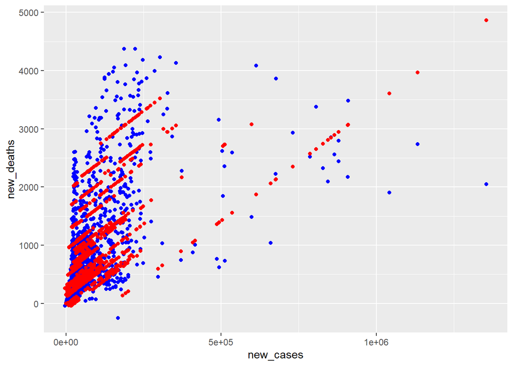

```r
US_tot_w_pred <- US_totals_dk %>% mutate(pred = predict(mod))

US_tot_w_pred %>%
  ggplot() +
  geom_point(aes(x = new_cases, y = new_deaths), color = 'blue') +
  geom_point(aes(x = new_cases, y = pred), color = 'red')
```

[figure not shown]

```r
US_tot_w_pred %>%
  group_by(Month_Yr) %>%
  summarise(Actual = sum(new_deaths),
            Prediction = sum(pred)) %>%
  ungroup() %>%
  pivot_longer(cols = c(Actual, Prediction)) %>%
  rename('Category' = name) %>%
  ggplot(aes(fill = Category, y=value, x=Month_Yr)) +
  geom_bar(position="dodge", stat="identity") +
  labs(title = "Deaths Per Thou by MonthYear - Predicted vs. Actual", y = NULL) +
  theme(axis.text.x = element_text(angle = 90))
```

# Bias

Bias I may have on the data include looking at the data from a retrospective lens, further from real-time, knowing the general progression of the disease overtime and the social habit evolution.

# Conclusion

In conclusion, there is a lot of ways to model and view historic COVID19 data. One could spend several weeks tilting and adding to the data in order to attempt to understand what occured, when and (maybe) why.

The predictions show a stratified linearity on cases to deaths and nice symmetry in prediction over the year months.